# Lattice Plots

Andrew Witherspoon

9/16/2018

Lattice functions generally take a formula for their first argurment, usually in the form:

```
xyplot(y ~ x | f * g, data)
```

To put this into words - I want to look at the scatterplot of y and x, for every level of f and g.

- Formula notion is used, hence the ~
- On the left of th ~ is y-axis variable, on the right is the x-axis variable
- f and g are *conditioning* variables - they are optional
- the * indicates an interaction between two variables
- The second argument is the data frame or the list from which the variables in the formula should be looked up
- If no tata frame or list is passed, then the parent frame is used
- If no other aguments are passed, there are defaults that can be used

Here is a simple scatterplot using xyplot() - a lattice plotting function

```r
library(lattice)
library(datasets)

xyplot(Ozone ~ Wind, data = airquality)
```

[output not shown]

Here’s a slightly more complicated lattice plot. Plotting Ozone and Wind, by month (each level of the variable month):

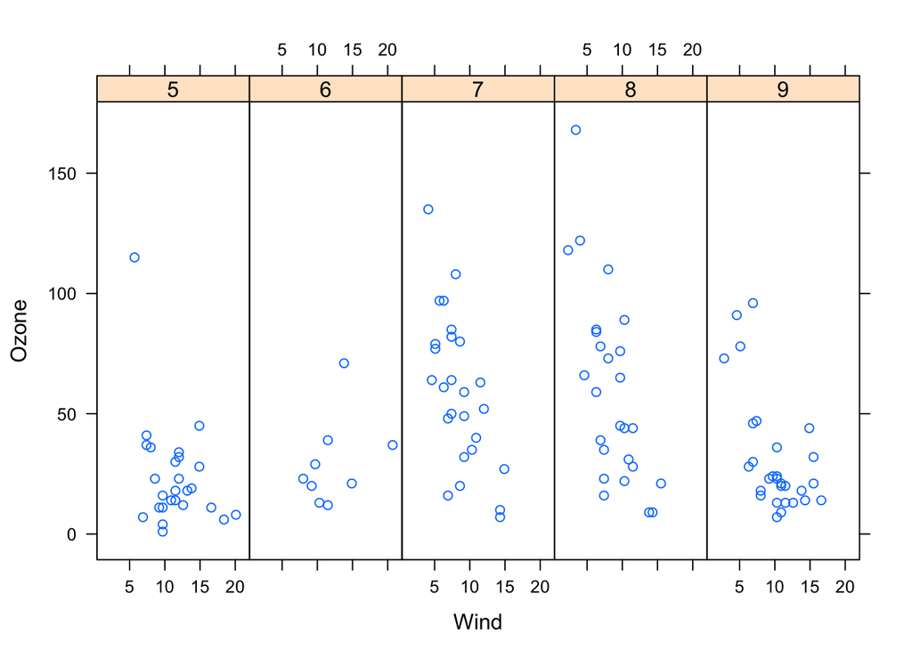

```r
#first, we will just convert 'Month' to a factor variable:
airquality <- transform(airquality, Month = factor(Month))

#note that this dataset only has data for months 5, 6, 7, 8, and 9

xyplot(Ozone ~ Wind | Month, data = airquality, layout = c(5,1))
```

Lattice functions don’t actually print directly to device (screen, PDF, png, etc.). They actually embed a print function into the plot function. When you call the plot function, the print function will happen automatically.

You can save the plot as an object, and it won’t print until you call the print function:

```r
p <- xyplot(Ozone ~ Wind, data = airquality)
```

Nothing happened…

Until we call the print() function:

```r
print(p)
```

[output not shown]

In normal use, it is autoprinted:

```r
xyplot(Ozone ~ Wind, data = airquality)
```

[output not shown]